# Object Detection in a maritime context

## Introduction

In this lab we want to go deeper into the comprehension and the use of object detection architectures by training maritime object detectors. We will start by training a Faster R-CNN object detector on a maritime Pascal VOC subset. Then we will redefine our need to retrain the model in a more efficient fashion. Then we'll analyse the performance of the model using metrics seen in class.

## Objectives

- Learn to use an object detector in pytorch and evaluate it.
- Select data and train a detector to meet an industry requirement.

## Getting started

Load all the necessary packages before starting.

```python
# import torch packages
import pandas as pd
import torch
import torch.nn as nn
import os
import time
from pathlib import Path
from torch.autograd import Variable
from PIL import Image
import torchvision
from torchvision.models.detection.faster_rcnn import FastRCNNPredictor

# import some common libraries
import matplotlib.pyplot as plt
import numpy as np
import cv2
from google.colab.patches import cv2_imshow
from google.colab import files, drive
```

## Exercise 1: What is the challenge ?

For the Unmanned Surface Vehicle (USV) we want to be able to detect all surrounding floating objects and classify them into one of the following categories.

1. boat
2. buoy
3. sail
4. person
5. kayak
6. motor_sail
7. ferry
8. vessel
9. zodiac
10. fishing_boat
11. OFNI
12. kite
13. windsurf
14. surfboard

For that purpose Eca Robotics has downloaded [Pascal VOC](http://host.robots.ox.ac.uk/pascal/VOC/) open dataset, filter only maritime images and reannotate them with interesting classes. Indeed Pascal VOC dataset only contains 20 categories and we kept images containing boat objects.

**Can you train a maritime object detector with that dataset ?**

Load the data and create stats on the classes to get a sense of the dataset.

```python
!gdown --id 1o6e6L0Lypc5_dMN0tLbxiUR7wcC5fkVU
```

```
Downloading...
From: https://drive.google.com/uc?id=1o6e6L0Lypc5_dMN0tLbxiUR7wcC5fkVU
To: /content/maritime_object_detection.zip
100% 59.0M/59.0M [00:00<00:00, 126MB/s]
```

```python
!unzip -oq maritime_object_detection.zip
```

```python
data_path = 'pascal_voc/train/'

# Create annotations dictionnary
anno_dict = {
    0: "boat",
    1: "buoy",
    2: "sail",
    3: "person",
    4: "kayak",
    5: "motor_sail",
    6: "ferry",
    7: "vessel",
    8: "zodiac",
    9: "fishing_boat",
    10: "OFNI",
    11: "kite",
    12: "windsurf",
    13: "surfboard"
}
```

We show an image to see the nature of the images.

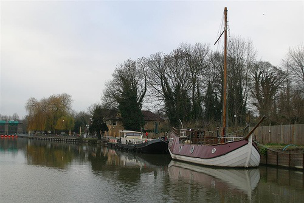

```python
from PIL import Image
Image.open(data_path + '2007_000061.jpg')
```

We want to count the number of occurences of each class in the 500+ files we have at our disposal.

```
TODO
1. read all txt files and iterate over them - Path and glob function,
2. filter labels.txt file,
3. using pandas to read column 0 and append it to the classes list,
4. concat the list into a pandas dataframe,
5. return the count using value_counts function
```

```python
# Get annotations from txt files
def count_objects(data_path):
  """
  Function reading all yolo format txt files and returning number of objects by class

  <object-class> <XCenterRelative> <YCenterRelative> <WidthRelative> <HeightRelative>
  <object-class> - integer number of object from 0 to (classes-1)
  <XCenterRelative> <YCenterRelative> - center of the bounding box [0,1]
  <WidthRelative> <HeightRelative> - width and height [0,1]
  """
  classes = []

  ### BEGIN SOLUTION

  ### END SOLUTION
```

```python
count_df = count_objects(data_path)
# If assert launch an error there is an error in your code, else it is OK.
assert len(count_df) == 14
count_df
```

```
3     572
0     416
4     170
2     165
1     149
5     139
6     113
7      66
9      55
8      37
10      8
12      3
11      2
13      1
Name: 0, dtype: int64
```

To improve readability replace index by class names using the dictionnary anno_dict.

```
TODO
Replace index by class names with one command
```

Hint : Use pandas.rename function.

```python
### BEGIN SOLUTION
count_df =
### END SOLUTION
assert count_df['sail'] == 165
count_df
```

```
person          572
boat            416
kayak           170
sail            165
buoy            149
motor_sail      139
ferry           113
vessel           66
fishing_boat     55
zodiac           37
OFNI              8
windsurf          3
kite              2
surfboard         1
Name: 0, dtype: int64
```

To improve the effectiveness of the TP we use a small dataset, which is still long to train. Futhermore the dataset is unbalanced, which is a difficulty to train a robust detector.

In industrial applications several thousands of annotations by class are needed to obtain an acceptable performance. We'll keep that in mind when analysing results.

## Exercise 2: Code a dataloader

To exploit the images and their annotations, we need to write a dataloader in order to iterate through the images in the Pytorch format.

The [torchvision reference scripts for training object detection, instance segmentation and person keypoint detection](https://github.com/pytorch/vision/tree/v0.3.0/references/detection) allows for easily supporting adding new custom datasets. The dataset should inherit from the standard `torch.utils.data.Dataset` class, and implement `__len__` and `__getitem__`.

The only specificity that we require is that the dataset `__getitem__` should return:

- image: a PIL Image of size (H, W)
- target: a dict containing the following fields
  - `boxes` (`FloatTensor[N, 4]`): the coordinates of the `N` bounding boxes in `[x0, y0, x1, y1]` format, ranging from `0` to `W` and `0` to `H`
  - `labels` (`Int64Tensor[N]`): the label for each bounding box
  - `image_id` (`Int64Tensor[1]`): an image identifier. It should be unique between all the images in the dataset, and is used during evaluation
  - `area` (`Tensor[N]`): The area of the bounding box. This is used during evaluation with the COCO metric, to separate the metric scores between small, medium and large boxes.
  - `iscrowd` (`UInt8Tensor[N]`): instances with `iscrowd=True` will be ignored during evaluation.
  - (optionally) `masks` (`UInt8Tensor[N, H, W]`): The segmentation masks for each one of the objects
  - (optionally) `keypoints` (`FloatTensor[N, K, 3]`): For each one of the `N` objects, it contains the `K` keypoints in `[x, y, visibility]` format, defining the object. `visibility=0` means that the keypoint is not visible. Note that for data augmentation, the notion of flipping a keypoint is dependent on the data representation, and you should probably adapt `references/detection/transforms.py` for your new keypoint representation

If your model returns the above methods, they will make it work for both training and evaluation, and will use the evaluation scripts from pycocotools.

One note on the labels. The model considers class 0 as background. **Then we need to modify class 0 - boat, in order to make a difference from the background. We will replace 0 by 14.**

```
TODO
Implement __getitem__ function by following comments in the code
```

```python
class VocDataset(torch.utils.data.Dataset):
  def __init__(self, root, transform=None):
    self.root = root
    self.transform = transform
    # load all image files, sorting them to ensure that they are aligned
    self.imgs = list(sorted(Path(root).glob('*.jpg')))
    self.bboxes = list(sorted(Path(root).glob('*.txt')))[:-1] # ignore labels.txt


  def __getitem__(self, idx):

    # BEGIN SOLUTION

    # get image and bounding boxes paths
    img_path =
    bbox_path =
    # open image and convert to RGB
    img =
    # get width and height
    width, height =
    # get bounding boxes
    bbox_df =

    # get bounding box coordinates
    # YOLO format reminder :
    # <object-class> <XCenterRelative> <YCenterRelative> <WidthRelative> <HeightRelative>
    boxes = []
    for index, row in bbox_df.iterrows():
      xmin =
      xmax =
      ymin =
      ymax =
      if xmin < xmax and ymin < ymax:
        boxes.append([xmin, ymin, xmax, ymax])

    # convert everything into a torch.Tensor
    boxes =
    # replace label 0 by 14
    labels =
    # convert labels to a torch.Tensor
    labels =

    # get image id
    image_id =
    # compute area of the bounding boxes
    area =
    # suppose all instances are not crowd
    iscrowd = torch.zeros((len(bbox_df),), dtype=torch.int64)

    # populate target dictionnary
    target = {}
    target["boxes"] =
    target["labels"] =
    target["image_id"] =
    target["area"] =
    target["iscrowd"] =

    ### END SOLUTION

    # image transformation
    if self.transform is not None:
      img, target = self.transform(img, target)

    return img, target


  def __len__(self):
    return len(self.imgs)
```

Let now get the result tuple for the first image and plot it with ground truth annotations to see if the data seems correctly read.

```python
dataset = VocDataset(data_path)
assert torch.equal(dataset[2][1]['area'], torch.tensor([22363.4668]))
assert torch.equal(dataset[1][1]['labels'], torch.tensor([14, 5, 14]))
dataset[0]
```

```
(<PIL.Image.Image image mode=RGB size=500x333 at 0x7FC9A5CF1C50>,
 {'area': tensor([43684.0117,  3559.0000]),
  'boxes': tensor([[274.0000,  10.9998, 437.0000, 278.9999],
          [187.3420, 214.0001, 281.0000, 252.0001]]),
  'image_id': tensor([0]),
  'iscrowd': tensor([0, 0]),
  'labels': tensor([5, 6])})
```

```python
import torchvision.transforms.functional as F

plt.rcParams["savefig.bbox"] = 'tight'

def show(imgs):
    if not isinstance(imgs, list):
        imgs = [imgs]
    fix, axs = plt.subplots(ncols=len(imgs), squeeze=False)
    for i, img in enumerate(imgs):
        img = img.detach()
        img = F.to_pil_image(img)
        axs[0, i].imshow(np.asarray(img))
        axs[0, i].set(xticklabels=[], yticklabels=[], xticks=[], yticks=[])
```

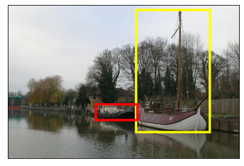

```python
from torchvision.io import read_image
from torchvision.utils import draw_bounding_boxes

img1_int = read_image(data_path + '/2007_000061.jpg')
colors = ["yellow", "red"]
result = draw_bounding_boxes(img1_int, dataset[0][1]['boxes'], colors=colors, width=5)
show(result)
```

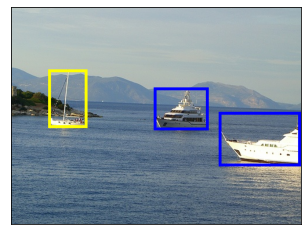

```python
img2_int = read_image(data_path + '/2007_000241.jpg')
colors = ["blue", "yellow", "blue"]
result = draw_bounding_boxes(img2_int, dataset[1][1]['boxes'], colors=colors, width=5)
show(result)
```

The dataloader seems to do the job. If you are curious about the dataset you can plot other images, or create a grib with several ones.

## Exercise 3: Define a model

In this tutorial, we will be using faster R-CNN as described in class. Faster R-CNN is a model that predicts both bounding boxes and class scores for potential objects in the image.

[figure not shown]

There are two common situations where one might want to modify one of the available models in torchvision modelzoo. The first is when we want to start from a pre-trained model, and just finetune the last layer. The other is when we want to replace the backbone of the model with a different one (for faster predictions, for example).

We are in the first case to use all the power of a pretrained model. We'll load Faster R-CNN with pretrained weights before retraining it on the images we have. By that means we accelerate the training of the model.

```
TODO
1. load a pretrained fasterrcnn_resnet50_fpn
2. get number of input features for the classifier
3. replace the pre-trained head with a new one
```

```python
def get_detection_model(num_classes=15):

  ### BEGIN SOLUTION

  # load a model pre-trained on COCO
  model =
  # get number of input features for the classifier
  in_features =
  # replace the pre-trained head with a new one
  model.roi_heads.box_predictor =

  ### END SOLUTION

  return model
```

```python
model = get_detection_model()
model
```

```
FasterRCNN(
  (transform): GeneralizedRCNNTransform(
      Normalize(mean=[0.485, 0.456, 0.406], std=[0.229, 0.224, 0.225])
      Resize(min_size=(800,), max_size=1333, mode='bilinear')
  )
  (backbone): BackboneWithFPN(
    (body): IntermediateLayerGetter(
      (conv1): Conv2d(3, 64, kernel_size=(7, 7), stride=(2, 2), padding=(3, 3), bias=False)
      (bn1): FrozenBatchNorm2d(64, eps=0.0)
      (relu): ReLU(inplace=True)
      (maxpool): MaxPool2d(kernel_size=3, stride=2, padding=1, dilation=1, ceil_mode=False)
      (layer1): Sequential(
        (0): Bottleneck(
          (conv1): Conv2d(64, 64, kernel_size=(1, 1), stride=(1, 1), bias=False)
          (bn1): FrozenBatchNorm2d(64, eps=0.0)
          (conv2): Conv2d(64, 64, kernel_size=(3, 3), stride=(1, 1), padding=(1, 1), bias=False)
          (bn2): FrozenBatchNorm2d(64, eps=0.0)
          (conv3): Conv2d(64, 256, kernel_size=(1, 1), stride=(1, 1), bias=False)
          (bn3): FrozenBatchNorm2d(256, eps=0.0)
          (relu): ReLU(inplace=True)
          (downsample): Sequential(
            (0): Conv2d(64, 256, kernel_size=(1, 1), stride=(1, 1), bias=False)
            (1): FrozenBatchNorm2d(256, eps=0.0)
          )
        )
        (1): Bottleneck(
          (conv1): Conv2d(256, 64, kernel_size=(1, 1), stride=(1, 1), bias=False)
          (bn1): FrozenBatchNorm2d(64, eps=0.0)
          (conv2): Conv2d(64, 64, kernel_size=(3, 3), stride=(1, 1), padding=(1, 1), bias=False)
          (bn2): FrozenBatchNorm2d(64, eps=0.0)
          (conv3): Conv2d(64, 256, kernel_size=(1, 1), stride=(1, 1), bias=False)
          (bn3): FrozenBatchNorm2d(256, eps=0.0)
          (relu): ReLU(inplace=True)
        )
        (2): Bottleneck(
          (conv1): Conv2d(256, 64, kernel_size=(1, 1), stride=(1, 1), bias=False)
          (bn1): FrozenBatchNorm2d(64, eps=0.0)
          (conv2): Conv2d(64, 64, kernel_size=(3, 3), stride=(1, 1), padding=(1, 1), bias=False)
          (bn2): FrozenBatchNorm2d(64, eps=0.0)
          (conv3): Conv2d(64, 256, kernel_size=(1, 1), stride=(1, 1), bias=False)
```

[output cut: 161 more lines]

```
      (bbox_pred): Conv2d(256, 12, kernel_size=(1, 1), stride=(1, 1))
    )
  )
  (roi_heads): RoIHeads(
    (box_roi_pool): MultiScaleRoIAlign(featmap_names=['0', '1', '2', '3'], output_size=(7, 7), sampling_ratio=2)
    (box_head): TwoMLPHead(
      (fc6): Linear(in_features=12544, out_features=1024, bias=True)
      (fc7): Linear(in_features=1024, out_features=1024, bias=True)
    )
    (box_predictor): FastRCNNPredictor(
      (cls_score): Linear(in_features=1024, out_features=15, bias=True)
      (bbox_pred): Linear(in_features=1024, out_features=60, bias=True)
    )
  )
)
```

## Exercise 4: Preparing training loop

In references/detection/, we have a number of helper functions to simplify training and evaluating detection models. Here, we will use references/detection/engine.py, references/detection/utils.py and references/detection/transforms.py.

Let's copy those files (and their dependencies) in here so that they are available in the notebook

```python
%%shell

# Download TorchVision repo to use some files from
# references/detection
git clone https://github.com/pytorch/vision.git
cd vision
git checkout v0.8.2

cp references/detection/utils.py ../
cp references/detection/transforms.py ../
cp references/detection/coco_eval.py ../
cp references/detection/engine.py ../
cp references/detection/coco_utils.py ../
```

```
fatal: destination path 'vision' already exists and is not an empty directory.
HEAD is now at 2f40a483 [v0.8.X] .circleci: Add Python 3.9 to CI (#3063)
```

### Data augmentation

To go deeper into the training process we want to do data augmentation by applying random transformations to the images. It allows the model to train longer without overfitting and augment programmatically the dataset size and the genericity of the model.

You can find the reference of the transformations here: https://pytorch.org/vision/stable/transforms.html

```python
import transforms as T

def get_transform(train):
    transform = []
    # converts the image, a PIL image, into a PyTorch Tensor
    # transform.append(transforms.ToTensor())
    transform.append(T.ToTensor())
    if train:

      ### BEGIN SOLUTION

      # during training randomly horizontal flip the training images - proba 0.5

      ## END SOLUTION

    return T.Compose(transform)
```

### Testing forward() method

Before iterating over the dataset, it’s good to see what the model expects during training and inference time on sample data.

```
TODO
Follow the comments on the next cell
```

```python
import utils

### BEGIN SOLUTION

# get model and dataset with augmentations
model =
dataset =

# create dataloader with torch.utils.data.DataLoader
data_loader = torch.utils.data.DataLoader(
    dataset,
    batch_size=2,
    shuffle=True,
    num_workers=2,
    collate_fn=utils.collate_fn
)

# For training
# get next batch images + targets by iterating on the data_loader
images, targets =
# Convert images and targets into the desired format by the model
# Hint : use list comprehension
images =
targets =
output =    # Returns losses and detections

### END SOLUTION
```

```python
# For inference
model.eval()
x = [torch.rand(3, 300, 400), torch.rand(3, 500, 400)]
predictions = model(x) # Returns predictions
predictions
```

```
[{'boxes': tensor([[373.8896,   9.4326, 398.8881, 208.1367],
          [341.8389,   6.9412, 397.8175, 200.3364],
          [331.3564,  80.0345, 335.8459,  85.0141],
          [332.1281,  78.8603, 336.5937,  83.3668],
          [262.3659,  16.7150, 371.0645, 181.1477],
          [131.3029, 211.7130, 135.1806, 215.8442],
          [332.1714, 229.7248, 336.4000, 233.4189],
          [139.2973, 216.6505, 143.1851, 220.4692],
          [234.8756,  94.0482, 239.8555, 100.2580],
          [125.2631, 225.0429, 128.8246, 229.6378],
          [332.5087,  81.0376, 337.2324,  85.5538],
          [112.8737,  35.2868, 323.6902, 124.2186],
          [130.3404, 212.6061, 133.8581, 216.9112],
          [332.1428, 231.1262, 336.4825, 234.8823],
          [130.0615, 210.2733, 134.0759, 214.4536],
          [124.6468, 226.5365, 128.0263, 230.6564],
          [175.1406,  60.9012, 179.0518,  64.7555],
          [ 12.6291,  19.6050, 109.3176, 168.6470],
          [175.5291,  58.9379, 179.7441,  62.8636],
          [299.2369, 137.9248, 303.5729, 142.5095],
          [ 14.7371,  51.6805,  95.7245, 226.1514],
          [192.7833,  91.4750, 196.7568,  95.5221],
          [275.6713, 222.9497, 279.7286, 227.4258],
          [ 68.5065, 108.9391,  72.5881, 113.4185],
          [331.6827,  82.8459, 335.8679,  87.2802],
          [ 67.2205,   9.6427, 255.7314, 137.1026],
          [137.8670, 216.1923, 141.3184, 219.8769],
          [191.8697,  90.8931, 195.5424,  95.0535],
          [128.7003, 219.8882, 132.0602, 224.4701],
          [148.0377, 215.5285, 152.1765, 220.6592],
          [ 69.5262, 109.3338,  73.9535, 114.0035],
          [130.1829, 220.2160, 133.5529, 224.3688],
          [293.6509, 127.0136, 297.4721, 131.5605],
          [331.1546, 232.3524, 335.3162, 235.8645],
          [141.8201,   4.1820, 400.0000, 107.5506],
          [ 83.1644,  80.8478,  87.8068,  85.6421],
          [ 93.7412, 179.0059,  97.6239, 183.0124],
          [146.8276, 215.2648, 150.9782, 220.1559],
          [324.0314, 124.9072, 328.1683, 129.4341],
          [330.5492, 233.8703, 334.6646, 237.0935],
```

[output cut: 181 more lines]

```
          1, 1, 1, 1, 1, 1, 1, 1, 1, 1, 1, 1, 1, 1, 1, 1, 1, 1, 1, 1, 1, 1, 1, 1,
          1, 1, 1, 1, 1, 1, 1, 1, 1, 1, 1, 1, 1, 1, 1, 1, 1, 1, 1, 1, 1, 1, 1, 1,
          1, 1, 1, 1]),
  'scores': tensor([0.1591, 0.1568, 0.1541, 0.1490, 0.1455, 0.1415, 0.1383, 0.1362, 0.1357,
          0.1346, 0.1342, 0.1325, 0.1323, 0.1320, 0.1320, 0.1313, 0.1311, 0.1308,
          0.1308, 0.1304, 0.1301, 0.1295, 0.1293, 0.1292, 0.1291, 0.1289, 0.1286,
          0.1286, 0.1285, 0.1280, 0.1278, 0.1278, 0.1276, 0.1275, 0.1275, 0.1274,
          0.1272, 0.1270, 0.1267, 0.1266, 0.1266, 0.1261, 0.1261, 0.1259, 0.1259,
          0.1259, 0.1256, 0.1256, 0.1255, 0.1254, 0.1253, 0.1250, 0.1250, 0.1250,
          0.1249, 0.1248, 0.1248, 0.1244, 0.1244, 0.1244, 0.1243, 0.1243, 0.1243,
          0.1239, 0.1238, 0.1238, 0.1236, 0.1235, 0.1235, 0.1235, 0.1234, 0.1233,
          0.1233, 0.1233, 0.1229, 0.1229, 0.1225, 0.1223, 0.1222, 0.1222, 0.1221,
          0.1221, 0.1218, 0.1217, 0.1217, 0.1216, 0.1216, 0.1216, 0.1216, 0.1215,
          0.1214, 0.1213, 0.1212, 0.1212, 0.1211, 0.1210, 0.1210, 0.1210, 0.1209,
          0.1208], grad_fn=<IndexBackward0>)}]
```

Note that we do not need to add a mean/std normalization nor image rescaling in the data transforms, as those are handled internally by the Faster R-CNN model.

## Exercise 5: Putting everything together

We now have the dataset class, the model, the data transform and a hint about the dataloader. Let's instantiate them to launch a full training process.

First we want to create train/test split for the training and apply dataloaders to each one.

```python
from engine import train_one_epoch, evaluate

### BEGIN SOLUTION

# use our dataset and defined transformations
dataset =
dataset_test =

# split the dataset in train and test set with torch.utils.data.Subset
torch.manual_seed(1)
indices = torch.randperm(len(dataset)).tolist()
dataset =
dataset_test =

# define training and validation data loaders
data_loader =

data_loader_test =

### END SOLUTION
```

Then, instantiate the model and the optimizer.

```python
device = torch.device('cuda') if torch.cuda.is_available() else torch.device('cpu')

# our dataset has 14 classes but bg class is set to 0
num_classes = 15

### BEGIN SOLUTION

# get the model using our helper function
model =
# move model to the right device


# construct an optimizer SGD with lr=0.005, momentum=0.9 and weight_decay=0.0005
params = [p for p in model.parameters() if p.requires_grad]
optimizer =

# and a learning rate scheduler which decreases the learning rate by 10x every 3 epochs
lr_scheduler =

### END SOLUTION
```

And now let's train the model for 3 epochs, evaluating at the end of every epoch.

It's time for you to take a 20 min break during the training.

```python
# let's train it for 3 epochs
num_epochs = 3

### BEGIN SOLUTION

for epoch in range(num_epochs):
    # train for one epoch, printing every 10 iterations
    # update the learning rate
    # evaluate on the test dataset

### END SOLUTION
```

```
Epoch: [0]  [  0/125]  eta: 0:06:40  lr: 0.000045  loss: 3.8613 (3.8613)  loss_classifier: 2.7122 (2.7122)  loss_box_reg: 0.2503 (0.2503)  loss_objectness: 0.7061 (0.7061)  loss_rpn_box_reg: 0.1927 (0.1927)  time: 3.2028  data: 0.3207  max mem: 6858
Epoch: [0]  [ 10/125]  eta: 0:07:08  lr: 0.000448  loss: 2.7326 (2.5964)  loss_classifier: 2.4074 (2.1312)  loss_box_reg: 0.2933 (0.3467)  loss_objectness: 0.0161 (0.0832)  loss_rpn_box_reg: 0.0173 (0.0353)  time: 3.7303  data: 0.0478  max mem: 8099
Epoch: [0]  [ 20/125]  eta: 0:06:06  lr: 0.000851  loss: 1.6877 (1.8923)  loss_classifier: 1.1530 (1.4453)  loss_box_reg: 0.3374 (0.3518)  loss_objectness: 0.0161 (0.0630)  loss_rpn_box_reg: 0.0227 (0.0322)  time: 3.5046  data: 0.0198  max mem: 8099
Epoch: [0]  [ 30/125]  eta: 0:05:38  lr: 0.001254  loss: 0.9885 (1.6097)  loss_classifier: 0.5606 (1.1768)  loss_box_reg: 0.3374 (0.3441)  loss_objectness: 0.0288 (0.0547)  loss_rpn_box_reg: 0.0229 (0.0341)  time: 3.4764  data: 0.0199  max mem: 8099
Epoch: [0]  [ 40/125]  eta: 0:05:16  lr: 0.001657  loss: 0.8245 (1.4048)  loss_classifier: 0.4029 (0.9852)  loss_box_reg: 0.3028 (0.3347)  loss_objectness: 0.0288 (0.0497)  loss_rpn_box_reg: 0.0250 (0.0352)  time: 3.9613  data: 0.0202  max mem: 9383
Epoch: [0]  [ 50/125]  eta: 0:04:35  lr: 0.002059  loss: 0.6245 (1.2412)  loss_classifier: 0.2812 (0.8454)  loss_box_reg: 0.2333 (0.3182)  loss_objectness: 0.0235 (0.0448)  loss_rpn_box_reg: 0.0250 (0.0327)  time: 3.8341  data: 0.0204  max mem: 9383
Epoch: [0]  [ 60/125]  eta: 0:03:57  lr: 0.002462  loss: 0.6033 (1.1525)  loss_classifier: 0.2730 (0.7552)  loss_box_reg: 0.2343 (0.3121)  loss_objectness: 0.0184 (0.0492)  loss_rpn_box_reg: 0.0259 (0.0360)  time: 3.5275  data: 0.0205  max mem: 9383
Epoch: [0]  [ 70/125]  eta: 0:03:17  lr: 0.002865  loss: 0.6480 (1.0814)  loss_classifier: 0.2947 (0.6900)  loss_box_reg: 0.2766 (0.3083)  loss_objectness: 0.0330 (0.0482)  loss_rpn_box_reg: 0.0224 (0.0349)  time: 3.3630  data: 0.0201  max mem: 9383
Epoch: [0]  [ 80/125]  eta: 0:02:41  lr: 0.003268  loss: 0.6710 (1.0377)  loss_classifier: 0.3044 (0.6491)  loss_box_reg: 0.3029 (0.3095)  loss_objectness: 0.0295 (0.0451)  loss_rpn_box_reg: 0.0224 (0.0339)  time: 3.3436  data: 0.0202  max mem: 9383
Epoch: [0]  [ 90/125]  eta: 0:02:07  lr: 0.003671  loss: 0.6807 (0.9952)  loss_classifier: 0.3242 (0.6106)  loss_box_reg: 0.3096 (0.3089)  loss_objectness: 0.0176 (0.0429)  loss_rpn_box_reg: 0.0227 (0.0328)  time: 3.8023  data: 0.0205  max mem: 9383
Epoch: [0]  [100/125]  eta: 0:01:30  lr: 0.004074  loss: 0.6165 (0.9798)  loss_classifier: 0.2260 (0.5750)  loss_box_reg: 0.3267 (0.3076)  loss_objectness: 0.0257 (0.0587)  loss_rpn_box_reg: 0.0207 (0.0385)  time: 3.8303  data: 0.0208  max mem: 9383
Epoch: [0]  [110/125]  eta: 0:00:54  lr: 0.004476  loss: 0.5678 (0.9408)  loss_classifier: 0.2166 (0.5446)  loss_box_reg: 0.2646 (0.3022)  loss_objectness: 0.0277 (0.0564)  loss_rpn_box_reg: 0.0233 (0.0376)  time: 3.6839  data: 0.0213  max mem: 9383
Epoch: [0]  [120/125]  eta: 0:00:18  lr: 0.004879  loss: 0.5862 (0.9139)  loss_classifier: 0.2361 (0.5222)  loss_box_reg: 0.2505 (0.3010)  loss_objectness: 0.0219 (0.0538)  loss_rpn_box_reg: 0.0227 (0.0370)  time: 3.7823  data: 0.0220  max mem: 9383
Epoch: [0]  [124/125]  eta: 0:00:03  lr: 0.005000  loss: 0.6030 (0.9025)  loss_classifier: 0.2559 (0.5132)  loss_box_reg: 0.3056 (0.3003)  loss_objectness: 0.0175 (0.0526)  loss_rpn_box_reg: 0.0195 (0.0364)  time: 3.6824  data: 0.0209  max mem: 9383
Epoch: [0] Total time: 0:07:34 (3.6364 s / it)
creating index...
index created!
Test:  [ 0/25]  eta: 0:00:29  model_time: 0.9422 (0.9422)  evaluator_time: 0.0134 (0.0134)  time: 1.1781  data: 0.2195  max mem: 9383
Test:  [24/25]  eta: 0:00:00  model_time: 0.7127 (0.7405)  evaluator_time: 0.0100 (0.0121)  time: 0.7658  data: 0.0099  max mem: 9383
Test: Total time: 0:00:19 (0.7766 s / it)
Averaged stats: model_time: 0.7127 (0.7405)  evaluator_time: 0.0100 (0.0121)
Accumulating evaluation results...
DONE (t=0.12s).
IoU metric: bbox
 Average Precision  (AP) @[ IoU=0.50:0.95 | area=   all | maxDets=100 ] = 0.124
 Average Precision  (AP) @[ IoU=0.50      | area=   all | maxDets=100 ] = 0.258
 Average Precision  (AP) @[ IoU=0.75      | area=   all | maxDets=100 ] = 0.108
 Average Precision  (AP) @[ IoU=0.50:0.95 | area= small | maxDets=100 ] = 0.157
 Average Precision  (AP) @[ IoU=0.50:0.95 | area=medium | maxDets=100 ] = 0.176
 Average Precision  (AP) @[ IoU=0.50:0.95 | area= large | maxDets=100 ] = 0.122
 Average Recall     (AR) @[ IoU=0.50:0.95 | area=   all | maxDets=  1 ] = 0.136
 Average Recall     (AR) @[ IoU=0.50:0.95 | area=   all | maxDets= 10 ] = 0.245
 Average Recall     (AR) @[ IoU=0.50:0.95 | area=   all | maxDets=100 ] = 0.251
 Average Recall     (AR) @[ IoU=0.50:0.95 | area= small | maxDets=100 ] = 0.265
 Average Recall     (AR) @[ IoU=0.50:0.95 | area=medium | maxDets=100 ] = 0.313
 Average Recall     (AR) @[ IoU=0.50:0.95 | area= large | maxDets=100 ] = 0.259
Epoch: [1]  [  0/125]  eta: 0:07:08  lr: 0.005000  loss: 0.3574 (0.3574)  loss_classifier: 0.1352 (0.1352)  loss_box_reg: 0.1806 (0.1806)  loss_objectness: 0.0194 (0.0194)  loss_rpn_box_reg: 0.0222 (0.0222)  time: 3.4304  data: 0.2993  max mem: 9383
Epoch: [1]  [ 10/125]  eta: 0:06:32  lr: 0.005000  loss: 0.5182 (0.5358)  loss_classifier: 0.2184 (0.2305)  loss_box_reg: 0.2121 (0.2475)  loss_objectness: 0.0194 (0.0287)  loss_rpn_box_reg: 0.0147 (0.0291)  time: 3.4134  data: 0.0468  max mem: 9383
Epoch: [1]  [ 20/125]  eta: 0:06:08  lr: 0.005000  loss: 0.4970 (0.5428)  loss_classifier: 0.2105 (0.2335)  loss_box_reg: 0.2471 (0.2516)  loss_objectness: 0.0136 (0.0249)  loss_rpn_box_reg: 0.0148 (0.0329)  time: 3.5118  data: 0.0214  max mem: 9383
Epoch: [1]  [ 30/125]  eta: 0:05:52  lr: 0.005000  loss: 0.4970 (0.5366)  loss_classifier: 0.2105 (0.2318)  loss_box_reg: 0.2471 (0.2501)  loss_objectness: 0.0150 (0.0232)  loss_rpn_box_reg: 0.0192 (0.0315)  time: 3.8736  data: 0.0212  max mem: 9383
```

[output cut: 53 more lines]

```
Accumulating evaluation results...
DONE (t=0.13s).
IoU metric: bbox
 Average Precision  (AP) @[ IoU=0.50:0.95 | area=   all | maxDets=100 ] = 0.199
 Average Precision  (AP) @[ IoU=0.50      | area=   all | maxDets=100 ] = 0.383
 Average Precision  (AP) @[ IoU=0.75      | area=   all | maxDets=100 ] = 0.151
 Average Precision  (AP) @[ IoU=0.50:0.95 | area= small | maxDets=100 ] = 0.163
 Average Precision  (AP) @[ IoU=0.50:0.95 | area=medium | maxDets=100 ] = 0.308
 Average Precision  (AP) @[ IoU=0.50:0.95 | area= large | maxDets=100 ] = 0.282
 Average Recall     (AR) @[ IoU=0.50:0.95 | area=   all | maxDets=  1 ] = 0.216
 Average Recall     (AR) @[ IoU=0.50:0.95 | area=   all | maxDets= 10 ] = 0.400
 Average Recall     (AR) @[ IoU=0.50:0.95 | area=   all | maxDets=100 ] = 0.435
 Average Recall     (AR) @[ IoU=0.50:0.95 | area= small | maxDets=100 ] = 0.380
 Average Recall     (AR) @[ IoU=0.50:0.95 | area=medium | maxDets=100 ] = 0.484
 Average Recall     (AR) @[ IoU=0.50:0.95 | area= large | maxDets=100 ] = 0.494
```

At each epoch, an evaluation process is launched to monitor the training. For the last epoch what AP do you get ?

### Checkpoints

We may now save the model and the state of optimizers and learning rate schedulers in order to continue training from where we left of. This is known as checkpointing.

```python
torch.save({
            'epoch': epoch,
            'model_state_dict': model.state_dict(),
            'optimizer_state_dict': optimizer.state_dict(),
            'lr_scheduler_state_dict': lr_scheduler.state_dict(),
            }, 'checkpoint.pt')
```

We can then re-create model, optimizer and lr_scheduler from scratch and simply load their state from the checkpoint file we have just saved.

In case you have not been able to train your model during the break or have lost your model for some reason we provide you a checkpoint from this link which you can download and upload it to Colab to continue with the lab: https://drive.google.com/file/d/1u-OA-XUGE3JA3czarnFInHLw-QQ22hFQ/view?usp=sharing

We may download it directly to Colab by doing:

```
gdown --id 1u-OA-XUGE3JA3czarnFInHLw-QQ22hFQ
```

```python
model = get_detection_model(num_classes)
# move model to the right device
model.to(device)

# construct an optimizer
params = [p for p in model.parameters() if p.requires_grad]
optimizer = torch.optim.SGD(params,
                            lr=0.005,
                            momentum=0.9,
                            weight_decay=0.0005)

# and a learning rate scheduler which decreases the learning rate by
# 10x every 3 epochs
lr_scheduler = torch.optim.lr_scheduler.StepLR(optimizer,
                                               step_size=3,
                                               gamma=0.1)

checkpoint = torch.load('checkpoint.pt')
model.load_state_dict(checkpoint['model_state_dict'])
optimizer.load_state_dict(checkpoint['optimizer_state_dict'])
lr_scheduler.load_state_dict(checkpoint['lr_scheduler_state_dict'])
epoch = checkpoint['epoch']

model.eval()
# - or -
model.train()
```

[output not shown]

[output cut: 161 more lines]

[output not shown]

## Exercise 6: Visualize the result on an image

Computer Vision has the great advantage to be visual. Le's check the prediction on a an image.

```python
from torchvision.transforms.functional import convert_image_dtype

# Batch images
batch_int = torch.stack([img1_int])
batch = convert_image_dtype(batch_int, dtype=torch.float).to(device)

model = model.eval()

# Print images with model prediction
outputs = model(batch)
print(outputs)
```

```
[{'boxes': tensor([[273.5561,   9.2671, 437.4469, 271.1135],
        [184.8196, 210.9068, 277.6950, 252.4231],
        [191.9558, 212.1546, 279.1857, 250.7074],
        [278.9582,  15.7147, 446.5796, 272.9711],
        [212.4917, 227.2171, 281.5651, 251.6042],
        [258.0365, 172.8879, 437.6261, 275.7717],
        [189.9194, 208.7554, 278.5433, 251.4874],
        [260.2405,   0.0000, 431.5128, 276.5837],
        [181.0404, 210.2408, 272.4010, 245.2574],
        [267.3173, 132.4125, 434.5537, 267.1310],
        [278.5862, 144.3155, 439.3300, 280.5137],
        [242.3364,  13.7182, 449.9167, 302.2907],
        [219.2940, 226.3231, 277.8358, 252.3154],
        [278.4956, 133.2818, 435.8320, 275.3340],
        [252.6492, 278.6701, 258.4290, 292.8037],
        [237.2321,  19.9732, 469.3909, 294.9556],
        [  0.0000, 202.2267, 271.5763, 242.1812]], device='cuda:0',
       grad_fn=<StackBackward0>), 'labels': tensor([ 5,  6, 14,  2, 14,  6,  7,  9,  9,  9,  7,  6,  4, 14,  1,  7,  6],
       device='cuda:0'), 'scores': tensor([0.4125, 0.4080, 0.3670, 0.3372, 0.2317, 0.1763, 0.1376, 0.1281, 0.0997,
        0.0968, 0.0964, 0.0871, 0.0712, 0.0689, 0.0683, 0.0653, 0.0621],
       device='cuda:0', grad_fn=<IndexBackward0>)}]
```

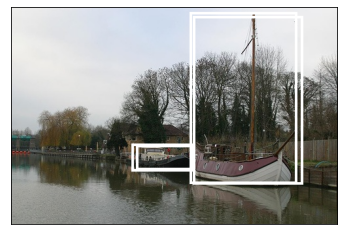

```python
# Select minimum threshold for keeping bbox
score_threshold = .3
# Show boxes
imgs_with_boxes = [
    draw_bounding_boxes(img_int,
                        boxes=output['boxes'][output['scores'] > score_threshold],
                        width=4)
    for img_int, output in zip(batch_int, outputs)
]
show(imgs_with_boxes)
```

Play with the score threshold.

Can you select a good trade-off threshold ?

Can you think of a technique to remove the duplicated bounding boxes ?

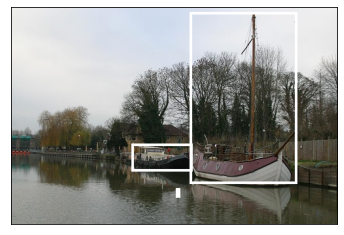

```python
# Apply the filtering solution
from torchvision import ops

### BEGIN SOLUTION

### END SOLUTION
```

```python
for img_int, output in zip(batch_int, outputs):
  toto = ops.nms(output['boxes'], output['scores'], iou_threshold=0.5)
  print(toto)
```

```
tensor([ 0,  1,  4,  5, 14, 16], device='cuda:0')
```

```python
for img_int, output in zip(batch_int, outputs):
  print(output['boxes'][toto])
```

```
tensor([[273.5561,   9.2671, 437.4469, 271.1135],
        [184.8196, 210.9068, 277.6950, 252.4231],
        [212.4917, 227.2171, 281.5651, 251.6042],
        [258.0365, 172.8879, 437.6261, 275.7717],
        [252.6492, 278.6701, 258.4290, 292.8037],
        [  0.0000, 202.2267, 271.5763, 242.1812]], device='cuda:0',
       grad_fn=<IndexBackward0>)
```

## Exercise 7: Create a MVP (Minimum Viable Product)

To cope with the small unbalanced dataset we have, two solutions are available

- Get more data on the internet or at sea, but we don't have time to search and annotate new data. Annotation is a faily time-consuming process. [Make a try](https://www.makesense.ai/)
- Merge classes to simplify the problem and balance the data.

For example in our case 14 categories is detailed. Indeed we want to be able to separate

- small_vessel -> [boat, motor_sail, zodiac]
- big_vessel -> [ferry, vessel, fishing_boat]
- sail_vessel -> [sail, windsurf, kite]
- human_powered_vessel -> [kayak, surfboard]
- person
- other -> [buoy, OFNI]

```
TODO
1. Modify the dictionnary of annotations.
2. Modify the dataLoader class to implement that merging process.
```

```python
# New maritime dictionnary for MVP
new_maritime_dict = {
    0: "small_vessel",
    1: "big_vessel",
    2: "sail_vessel",
    3: "human_powered_vessel",
    4: "person",
    5: "other"
}
```

```python
# Create a dictionnary to convert labels
merging_dict = {
    0: 0,
    1: 5,
    2: 2,
    3: 4,
    4: 3,
    5: 0,
    6: 1,
    7: 1,
    8: 0,
    9: 1,
    10: 5,
    11: 2,
    12: 2,
    13: 3
}
```

Recreate count of all images to recreate class balance. You can use the function from exercise 1.

```python
# Get annotations from txt files
def mvp_count_objects(data_path):
  """
  Function reading all txt files from a yolo format and returning number of objects by class

  <object-class> <XCenterRelative> <YCenterRelative> <WidthRelative> <HeightRelative>
  <object-class> - integer number of object from 0 to (classes-1)
  <XCenterRelative> <YCenterRelative> - center of the bounding box [0,1]
  <WidthRelative> <HeightRelative> - width and height [0,1]
  """
  classes = []

  ### BEGIN SOLUTION

  ### END SOLUTION
```

```python
# apply count and rename classes
### BEGIN SOLUTION
count_df =
### END SOLUTION
assert count_df['sail_vessel'] == 170
count_df
```

```
small_vessel            592
person                  572
big_vessel              234
human_powered_vessel    171
sail_vessel             170
other                   157
Name: 0, dtype: int64
```

Now that we can see that the dataset is more balanced, let's modify the dataloader to modify the class during the loading of the data.

```python
class VocDataset(torch.utils.data.Dataset):
  def __init__(self, root, transform=None):
    self.root = root
    self.transform = transform
    # load all image files, sorting them to ensure that they are aligned
    self.imgs = list(sorted(Path(root).glob('*.jpg')))
    self.bboxes = list(sorted(Path(root).glob('*.txt')))[:-1] # ignore labels.txt


  def __getitem__(self, idx):

    # get image and bounding boxes paths
    img_path = os.path.join(self.imgs[idx])
    bbox_path = os.path.join(self.bboxes[idx])
    # open image and convert to RGB
    img = Image.open(img_path).convert("RGB")
    # get width and height
    width, height = img.size
    # get bounding boxes
    bbox_df = pd.read_csv(bbox_path, sep=' ', header=None)

    # get bounding box coordinates
    # YOLO format reminder :
    # <object-class> <XCenterRelative> <YCenterRelative> <WidthRelative> <HeightRelative>
    boxes = []
    for index, row in bbox_df.iterrows():
      xmin = (row[1] - (row[3] / 2)) * width
      xmax = (row[1] + (row[3] / 2)) * width
      ymin = (row[2] - (row[4] / 2)) * height
      ymax = (row[2] + (row[4] / 2)) * height
      if xmin < xmax and ymin < ymax:
        boxes.append([xmin, ymin, xmax, ymax])

    # convert everything into a torch.Tensor
    boxes = torch.as_tensor(boxes, dtype=torch.float32)

    ## BEGIN SOLUTION

    # replace labels with new dict
    labels =
    # replace label 0 by 6
    labels =
    # convert labels to a torch.Tensor
    labels =

    ### END SOLUTION

    # get image od
    image_id = torch.tensor([idx])
    # compute area of the bounding boxes
    area = (boxes[:, 3] - boxes[:, 1]) * (boxes[:, 2] - boxes[:, 0])
    # suppose all instances are not crowd
    iscrowd = torch.zeros((len(bbox_df),), dtype=torch.int64)

    # populate target dictionnary
    target = {}
    target["boxes"] = boxes
    target["labels"] = labels
    target["image_id"] = image_id
    target["area"] = area
    target["iscrowd"] = iscrowd

    # image transformation
    if self.transform is not None:
      img, target = self.transform(img, target)

    return img, target


  def __len__(self):
    return len(self.imgs)
```

```python
dataset = VocDataset(data_path)
assert torch.equal(dataset[0][1]['labels'], torch.tensor([6,1]))
dataset[0]
```

```
(<PIL.Image.Image image mode=RGB size=500x333 at 0x7FC98A18A090>,
 {'area': tensor([43684.0117,  3559.0000]),
  'boxes': tensor([[274.0000,  10.9998, 437.0000, 278.9999],
          [187.3420, 214.0001, 281.0000, 252.0001]]),
  'image_id': tensor([0]),
  'iscrowd': tensor([0, 0]),
  'labels': tensor([6, 1])})
```

Labels [5, 6] have been transformed to [6, 1]

## Exercise 8: Retrain the model

Train the model with the new dataset.

Take code already written in exercise 5 and modify it to train the model again.

```python
### BEGIN SOLUTION

### END SOLUTION
```

```
Epoch: [0]  [  0/125]  eta: 0:07:55  lr: 0.000045  loss: 2.4222 (2.4222)  loss_classifier: 1.9238 (1.9238)  loss_box_reg: 0.3837 (0.3837)  loss_objectness: 0.0560 (0.0560)  loss_rpn_box_reg: 0.0587 (0.0587)  time: 3.8057  data: 0.3052  max mem: 9383
Epoch: [0]  [ 10/125]  eta: 0:07:19  lr: 0.000448  loss: 2.3169 (2.3260)  loss_classifier: 1.8793 (1.8777)  loss_box_reg: 0.3428 (0.3838)  loss_objectness: 0.0205 (0.0339)  loss_rpn_box_reg: 0.0277 (0.0307)  time: 3.8196  data: 0.0482  max mem: 9383
Epoch: [0]  [ 20/125]  eta: 0:06:43  lr: 0.000851  loss: 2.2670 (2.3077)  loss_classifier: 1.8884 (1.8887)  loss_box_reg: 0.3428 (0.3663)  loss_objectness: 0.0150 (0.0247)  loss_rpn_box_reg: 0.0188 (0.0280)  time: 3.8403  data: 0.0218  max mem: 9383
Epoch: [0]  [ 30/125]  eta: 0:05:52  lr: 0.001254  loss: 2.3094 (2.3210)  loss_classifier: 1.9055 (1.8897)  loss_box_reg: 0.3839 (0.3786)  loss_objectness: 0.0145 (0.0260)  loss_rpn_box_reg: 0.0154 (0.0267)  time: 3.6489  data: 0.0207  max mem: 9383
Epoch: [0]  [ 40/125]  eta: 0:05:13  lr: 0.001657  loss: 2.3268 (2.3918)  loss_classifier: 1.8881 (1.8875)  loss_box_reg: 0.4028 (0.3807)  loss_objectness: 0.0193 (0.0782)  loss_rpn_box_reg: 0.0183 (0.0453)  time: 3.5312  data: 0.0207  max mem: 9383
Epoch: [0]  [ 50/125]  eta: 0:04:34  lr: 0.002059  loss: 2.2371 (2.3721)  loss_classifier: 1.8925 (1.8899)  loss_box_reg: 0.3027 (0.3762)  loss_objectness: 0.0183 (0.0661)  loss_rpn_box_reg: 0.0137 (0.0398)  time: 3.5987  data: 0.0215  max mem: 9383
Epoch: [0]  [ 60/125]  eta: 0:03:59  lr: 0.002462  loss: 2.2936 (2.3684)  loss_classifier: 1.9067 (1.8892)  loss_box_reg: 0.3134 (0.3788)  loss_objectness: 0.0199 (0.0602)  loss_rpn_box_reg: 0.0181 (0.0401)  time: 3.6893  data: 0.0214  max mem: 9383
Epoch: [0]  [ 70/125]  eta: 0:03:24  lr: 0.002865  loss: 2.2936 (2.3493)  loss_classifier: 1.8906 (1.8880)  loss_box_reg: 0.3328 (0.3706)  loss_objectness: 0.0190 (0.0538)  loss_rpn_box_reg: 0.0210 (0.0369)  time: 3.8701  data: 0.0212  max mem: 9383
Epoch: [0]  [ 80/125]  eta: 0:02:45  lr: 0.003268  loss: 2.2663 (2.3411)  loss_classifier: 1.8647 (1.8855)  loss_box_reg: 0.3287 (0.3642)  loss_objectness: 0.0206 (0.0548)  loss_rpn_box_reg: 0.0205 (0.0365)  time: 3.6744  data: 0.0214  max mem: 9383
Epoch: [0]  [ 90/125]  eta: 0:02:09  lr: 0.003671  loss: 2.2746 (2.3402)  loss_classifier: 1.8909 (1.8884)  loss_box_reg: 0.3190 (0.3642)  loss_objectness: 0.0206 (0.0507)  loss_rpn_box_reg: 0.0245 (0.0369)  time: 3.6141  data: 0.0212  max mem: 9383
Epoch: [0]  [100/125]  eta: 0:01:33  lr: 0.004074  loss: 2.3376 (2.3505)  loss_classifier: 1.9043 (1.8879)  loss_box_reg: 0.3190 (0.3626)  loss_objectness: 0.0127 (0.0621)  loss_rpn_box_reg: 0.0252 (0.0379)  time: 3.9224  data: 0.0216  max mem: 9383
Epoch: [0]  [110/125]  eta: 0:00:55  lr: 0.004476  loss: 2.3264 (2.3460)  loss_classifier: 1.8967 (1.8885)  loss_box_reg: 0.3746 (0.3598)  loss_objectness: 0.0350 (0.0600)  loss_rpn_box_reg: 0.0234 (0.0377)  time: 3.7558  data: 0.0210  max mem: 9383
Epoch: [0]  [120/125]  eta: 0:00:18  lr: 0.004879  loss: 2.2203 (2.3412)  loss_classifier: 1.8746 (1.8886)  loss_box_reg: 0.3104 (0.3577)  loss_objectness: 0.0237 (0.0574)  loss_rpn_box_reg: 0.0223 (0.0375)  time: 3.5572  data: 0.0200  max mem: 9383
Epoch: [0]  [124/125]  eta: 0:00:03  lr: 0.005000  loss: 2.2967 (2.3407)  loss_classifier: 1.8785 (1.8881)  loss_box_reg: 0.3146 (0.3591)  loss_objectness: 0.0304 (0.0566)  loss_rpn_box_reg: 0.0223 (0.0369)  time: 3.5345  data: 0.0199  max mem: 9383
Epoch: [0] Total time: 0:07:42 (3.6966 s / it)
creating index...
index created!
Test:  [ 0/25]  eta: 0:00:31  model_time: 0.9929 (0.9929)  evaluator_time: 0.0128 (0.0128)  time: 1.2437  data: 0.2357  max mem: 9383
Test:  [24/25]  eta: 0:00:00  model_time: 0.7211 (0.7527)  evaluator_time: 0.0154 (0.0206)  time: 0.7820  data: 0.0116  max mem: 9383
Test: Total time: 0:00:19 (0.7994 s / it)
Averaged stats: model_time: 0.7211 (0.7527)  evaluator_time: 0.0154 (0.0206)
Accumulating evaluation results...
DONE (t=0.09s).
IoU metric: bbox
 Average Precision  (AP) @[ IoU=0.50:0.95 | area=   all | maxDets=100 ] = 0.000
 Average Precision  (AP) @[ IoU=0.50      | area=   all | maxDets=100 ] = 0.000
 Average Precision  (AP) @[ IoU=0.75      | area=   all | maxDets=100 ] = 0.000
 Average Precision  (AP) @[ IoU=0.50:0.95 | area= small | maxDets=100 ] = 0.000
 Average Precision  (AP) @[ IoU=0.50:0.95 | area=medium | maxDets=100 ] = 0.000
 Average Precision  (AP) @[ IoU=0.50:0.95 | area= large | maxDets=100 ] = 0.000
 Average Recall     (AR) @[ IoU=0.50:0.95 | area=   all | maxDets=  1 ] = 0.000
 Average Recall     (AR) @[ IoU=0.50:0.95 | area=   all | maxDets= 10 ] = 0.000
 Average Recall     (AR) @[ IoU=0.50:0.95 | area=   all | maxDets=100 ] = 0.012
 Average Recall     (AR) @[ IoU=0.50:0.95 | area= small | maxDets=100 ] = 0.018
 Average Recall     (AR) @[ IoU=0.50:0.95 | area=medium | maxDets=100 ] = 0.006
 Average Recall     (AR) @[ IoU=0.50:0.95 | area= large | maxDets=100 ] = 0.006
Epoch: [1]  [  0/125]  eta: 0:07:05  lr: 0.005000  loss: 2.3008 (2.3008)  loss_classifier: 1.8794 (1.8794)  loss_box_reg: 0.3504 (0.3504)  loss_objectness: 0.0309 (0.0309)  loss_rpn_box_reg: 0.0402 (0.0402)  time: 3.4054  data: 0.3149  max mem: 9383
Epoch: [1]  [ 10/125]  eta: 0:07:21  lr: 0.005000  loss: 2.3008 (2.3686)  loss_classifier: 1.8923 (1.8957)  loss_box_reg: 0.3645 (0.3974)  loss_objectness: 0.0175 (0.0336)  loss_rpn_box_reg: 0.0250 (0.0419)  time: 3.8357  data: 0.0484  max mem: 9383
Epoch: [1]  [ 20/125]  eta: 0:06:39  lr: 0.005000  loss: 2.2972 (2.3517)  loss_classifier: 1.8928 (1.8952)  loss_box_reg: 0.3645 (0.3912)  loss_objectness: 0.0175 (0.0305)  loss_rpn_box_reg: 0.0186 (0.0349)  time: 3.8214  data: 0.0213  max mem: 9383
Epoch: [1]  [ 30/125]  eta: 0:05:57  lr: 0.005000  loss: 2.3601 (2.3358)  loss_classifier: 1.8953 (1.8953)  loss_box_reg: 0.3504 (0.3802)  loss_objectness: 0.0230 (0.0292)  loss_rpn_box_reg: 0.0173 (0.0311)  time: 3.7198  data: 0.0213  max mem: 9383
```

[output cut: 53 more lines]

```
Accumulating evaluation results...
DONE (t=0.09s).
IoU metric: bbox
 Average Precision  (AP) @[ IoU=0.50:0.95 | area=   all | maxDets=100 ] = 0.000
 Average Precision  (AP) @[ IoU=0.50      | area=   all | maxDets=100 ] = 0.000
 Average Precision  (AP) @[ IoU=0.75      | area=   all | maxDets=100 ] = 0.000
 Average Precision  (AP) @[ IoU=0.50:0.95 | area= small | maxDets=100 ] = 0.000
 Average Precision  (AP) @[ IoU=0.50:0.95 | area=medium | maxDets=100 ] = 0.000
 Average Precision  (AP) @[ IoU=0.50:0.95 | area= large | maxDets=100 ] = 0.000
 Average Recall     (AR) @[ IoU=0.50:0.95 | area=   all | maxDets=  1 ] = 0.000
 Average Recall     (AR) @[ IoU=0.50:0.95 | area=   all | maxDets= 10 ] = 0.000
 Average Recall     (AR) @[ IoU=0.50:0.95 | area=   all | maxDets=100 ] = 0.012
 Average Recall     (AR) @[ IoU=0.50:0.95 | area= small | maxDets=100 ] = 0.018
 Average Recall     (AR) @[ IoU=0.50:0.95 | area=medium | maxDets=100 ] = 0.006
 Average Recall     (AR) @[ IoU=0.50:0.95 | area= large | maxDets=100 ] = 0.006
```

Can you explain the new AP score of the model on this simpler dataset ?

## Exercise 9: Test on new images

Take images on Google or where you want to apply the model on it, in a maritime context or in completely different one.

Try to answer those questions with empirical test:

1. Is the model good on all situation ?
2. Can you see a difference on small/medium/large objects ?
3. Can you isolate difficult images for it ?
4. Easy ones ?
5. Do you have good accuracy on different weather ?
6. Considering your answers how could you improve the dataset to improve the training of the model ?

## Optional Exercise 10: Train another model of your choice

To go deeper with object detection, you can try different models. A list of all available models is accessible in the [model zoo](https://pytorch.org/vision/stable/models.html).